# ADHD management

### Control Types

| control | n |
| --- | --- |
| Placebo | 1 |

| ID | measure | yi | se | study.design |
| --- | --- | --- | --- | --- |
| Surman 2019{#1759} 5-MTHF | Insomnia | 0.32 | 0.35 | RCT |

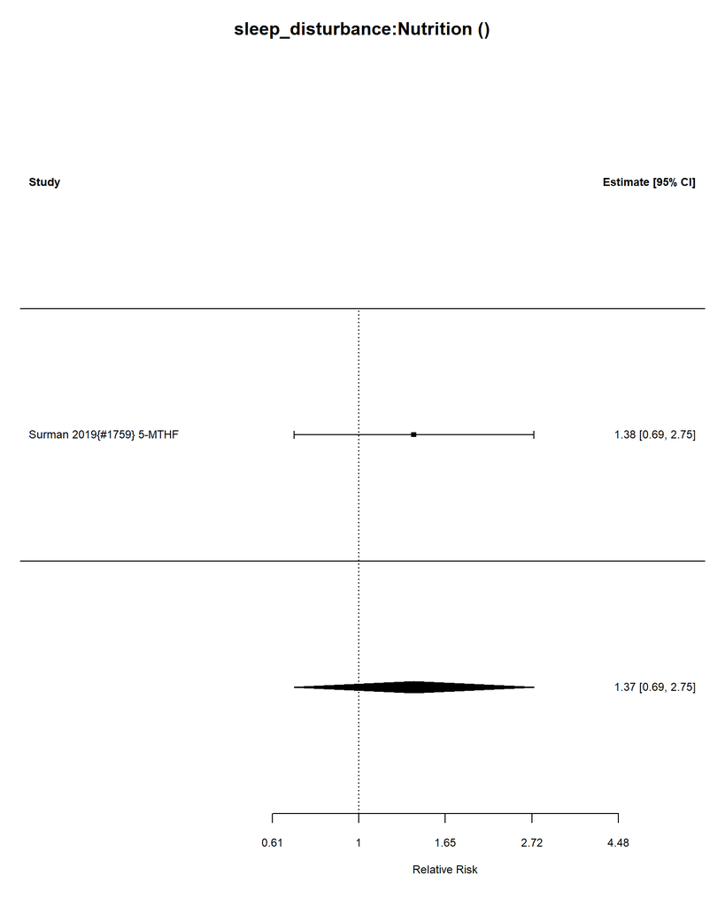

Number of studies = 1  
Intervention sample = 22  
Control sample = 22  
Total sample = 44

### Relative Risk Estimate

|  | estimate | se | zval | pval | ci.lb | ci.ub |
| --- | --- | --- | --- | --- | --- | --- |
| intrcpt | 1.377128 | 1.419067 | 2.459603 | 1.447735 | 0.6907343 | 2.745601 |

I-squared = 0 %

### Outcome: AEs:continuous Intervention: Nutrition

No data #1.

### Outcome: AEs:categorical Intervention: Nutrition

Outcome name: AEs Analyzing 1 studies.

Analyzing 1 studies.

### Control Types

| control | n |
| --- | --- |
| Placebo | 1 |

| ID | measure | yi | se | study.design |
| --- | --- | --- | --- | --- |
| Surman 2019{#1759} 5-MTHF | Number of participants with adverse events | 0.05 | 0.11 | RCT |

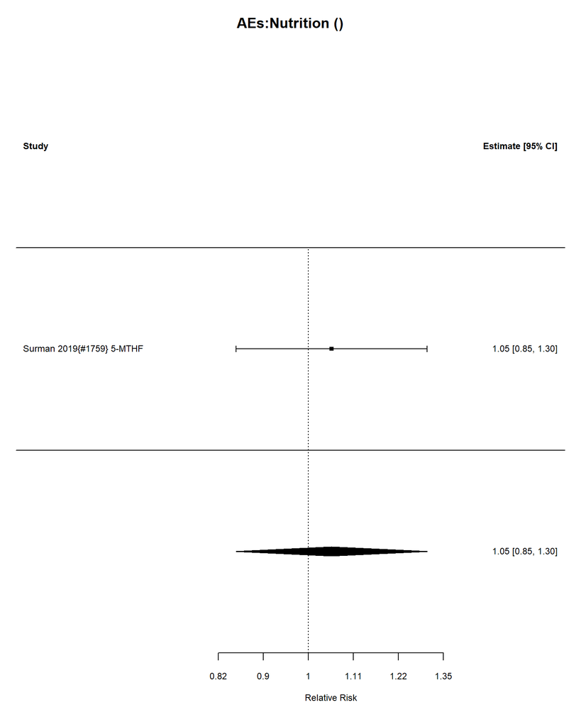

Number of studies = 1  
Intervention sample = 22  
Control sample = 22  
Total sample = 44

### Relative Risk Estimate

|  | estimate | se | zval | pval | ci.lb | ci.ub |
| --- | --- | --- | --- | --- | --- | --- |
| intrcpt | 1.051271 | 1.116278 | 1.599994 | 1.896481 | 0.8521438 | 1.29693 |

I-squared = 0 %

### Outcome: mortality:continuous Intervention: Nutrition

No data #1.

### Outcome: mortality:categorical Intervention: Nutrition

Outcome name: mortality Analyzing 2 studies.

Analyzing 2 studies.

### Control Types

| control | n |
| --- | --- |
| Placebo | 2 |

| ID | measure | yi | se | study.design |
| --- | --- | --- | --- | --- |
| Surman 2019{#1759} 5-MTHF | All-cause mortality | 0 | 1.98 | RCT |
| Pazoki, 2022{#7873} Saffron | Number of deaths | 0 | 1.98 | RCT |

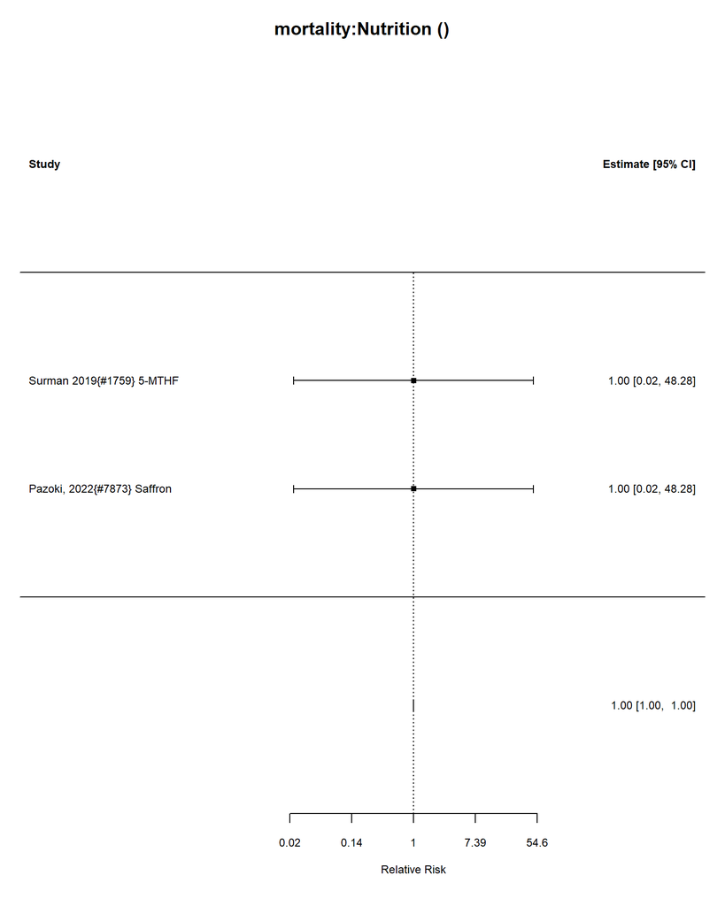

Number of studies = 2  
Intervention sample = 44  
Control sample = 44  
Total sample = 88

### Relative Risk Estimate

|  | estimate | se | tval | df | pval | ci.lb | ci.ub |
| --- | --- | --- | --- | --- | --- | --- | --- |
| intrcpt | 1 | 1 | NaN | 2.718282 | NaN | 1 | 1 |

I-squared = 0 %

### Outcome: behavior:continuous Intervention: Nutrition

No data #1.

### Outcome: behavior:categorical Intervention: Nutrition

Outcome name: behavior Analyzing 0 studies.

No data.

### Outcome: appetite:continuous Intervention: Nutrition

No data #1.

### Outcome: appetite:categorical Intervention: Nutrition

Outcome name: appetite Analyzing 2 studies.

Analyzing 2 studies.

### Control Types

| control | n |
| --- | --- |
| Placebo | 2 |

| ID | measure | yi | se | study.design |
| --- | --- | --- | --- | --- |
| Surman 2019{#1759} 5-MTHF | Decreased appetite adverse event | 1.13 | 0.60 | RCT |
| Pazoki, 2022{#7873} Saffron | Decreased appetite adverse event | -0.13 | 0.25 | RCT |

[figure not shown]

Number of studies = 2  
Intervention sample = 50  
Control sample = 47  
Total sample = 97

### Relative Risk Estimate

|  | estimate | se | tval | df | pval | ci.lb | ci.ub |
| --- | --- | --- | --- | --- | --- | --- | --- |
| intrcpt | 1.462285 | 1.858928 | 1.840431 | 2.718282 | 1.915541 | 0.0005586 | 3827.626 |

I-squared = 73 %

### Outcome: mood:continuous Intervention: Nutrition

No data #1.

### Outcome: mood:categorical Intervention: Nutrition

Outcome name: mood Analyzing 0 studies.

No data.

# Intervention: Psychosocial

### Outcome: functional:continuous Intervention: Psychosocial

| ID | measure | mean_ctrl_cont | SD_ctrl_cont | n_ctrl_cont | mean_int_cont | SD_int_cont | n_int_cont | yi | se | study.design |
| --- | --- | --- | --- | --- | --- | --- | --- | --- | --- | --- |
| Grinblat, 2023{#1358} | COPM (Canadian Occupational Performance Measure) | 3.73 | 2.15 | 46 | 6.22 | 2.12 | 46 | -1.1564972 | 0.2252714 | RCT |
| Antshel, 2026{#15276} CBT | BFIS-DR (Barkley Functional Impairment Scale Daily Responsibilities) | 6.89 | 1.32 | 78 | 5.45 | 1.56 | 76 | -0.9927007 | 0.1708155 | RCT |
| D’Amelio, 2026{#15404} CBT | WSAS (Work and Social Adjustment Scale) | 23.00 | 7.00 | 173 | 19.50 | 7.30 | 164 | -0.4885815 | 0.1105987 | RCT |
| Dittner, 2018{#1261} CBT | WSAS (Work and Social Adjustment Scale) to measure impairment in functioning | 16.80 | 8.80 | 30 | 10.20 | 6.90 | 30 | -0.8238266 | 0.2689283 | RCT |
| Moell, 2015{#8589} CBT | SDS (Sheehan Disability Scale) | 19.04 | 6.20 | 28 | 16.46 | 8.97 | 26 | -0.3320234 | 0.2742199 | RCT |
| Nasri, 2023{#2954} CBT | SDS (Sheehan Disability Scale) | 15.00 | 8.16 | 31 | 14.00 | 7.65 | 30 | -0.1247531 | 0.2563571 | RCT |
| Ulusoy, 2024{#3386} DBT | FAST (Functioning Assessment Short Test) | 34.44 | 13.92 | 16 | 26.94 | 10.78 | 16 | -0.5872300 | 0.3610929 | RCT |
| Dymphie, 2017{#10657} Goal man. | CIBIC (Clinician’s Interview-Based Impression of Change) evaluating 6 areas of functioning | 3.10 | 0.80 | 15 | 2.50 | 0.50 | 12 | -0.8500722 | 0.4042053 | RCT |
| Janssen, 2019{#1416} MBCT | OQ (Outcome Questionnaire) measuring general functioning | 61.40 | 21.00 | 51 | 59.10 | 18.20 | 45 | -0.1155888 | 0.2046940 | RCT |

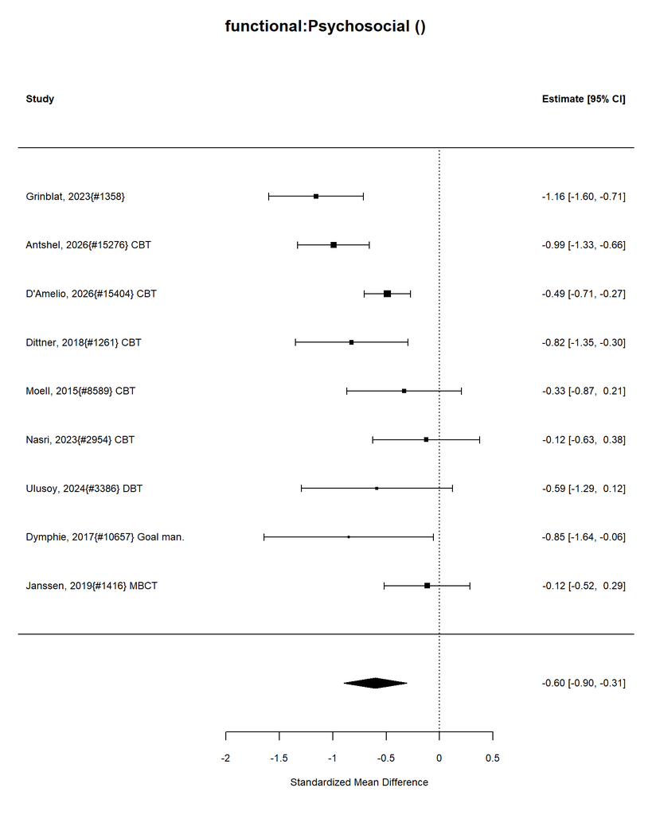

| estimate | conf.low | conf.high |
| --- | --- | --- |
| -0.6 | -0.9 | -0.31 |

Number of studies = 9

Intervention sample = 445

Control sample = 468

Total sample = 913.

I-squared = 68 %

Convert Effect Size to Real Units

Estimated effect in original units = -4.64.

##### Publication Bias Tests

###### Begg (non-parametric)

Rank Correlation Test for Funnel Plot Asymmetry Kendall’s tau = -0.1111, p = 0.7614

###### Egger (parametric)

Regression Test for Funnel Plot Asymmetry

Model: mixed-effects meta-regression model Predictor: standard error

Test for Funnel Plot Asymmetry: t = -0.1236, df = 7, p = 0.9051 Limit Estimate (as sei -> 0): b = -0.5541 (CI: -1.5322, 0.4239)

###### Trim and Fill

Estimate and Cis

|  | estimate | ci.lb | ci.ub |
| --- | --- | --- | --- |
| intrcpt | -0.6 | -0.9 | -0.31 |

### Meta-regression: stimulant vs non-stimulant

0 stimulant studies

0 nonstimulant studies

Not enough studies to compare stimulant and nonstimulant

### Meta-regression: AMPH vs MPH

### AMPH vs MPH meta-regression

0n AMPH studies

0 nMPH studies

Not enough studies to compare AMPH and MPH

## Meta-regression: Indirect comparison between combined vs(medication plus psychosocial) and medication

0 medication studies

0 combined studies

Not enough studies to compare medication and combined

## Meta-regression: Indirect comparison between combined vs(medication plus psychosocial) and psychosocial

9 psychosocial studies

0 combined studies

Not enough studies to compare psychosocial and combined

### Outcome: functional:categorical Intervention: Psychosocial

Outcome name: functional Analyzing 0 studies.

No data.

### Outcome: cognitive:continuous Intervention: Psychosocial

| ID | measure | mean_ctrl_cont | SD_ctrl_cont | n_ctrl_cont | mean_int_cont | SD_int_cont | n_int_cont | yi | se | study.design |
| --- | --- | --- | --- | --- | --- | --- | --- | --- | --- | --- |
| Virta, 2010{#3410} CBT | CNSVS ( Central Nervous System Vital Signs computerized neurocognitive test battery) neurocognitive index | 102.50 | 10.10 | 10 | 97.60 | 9.20 | 10 | -0.4857382 | 0.4537604 | RCT |
| Fleming, 2015{#1314} DBT | CPT-2 (Conners’ Continuous Performance Test–2nd edition) | 52.04 | 19.95 | 16 | 46.26 | 6.95 | 17 | 0.3823379 | 0.3514803 | RCT |
| Dymphie, 2017{#10657} Goal man. | Zoo map test, planning time | 39.90 | 35.40 | 15 | 71.10 | 73.60 | 12 | 0.5446578 | 0.3943267 | RCT |
| Gu, 2018{#1360} MBCT | ANT (Attentional Network Test), alerting reaction time | 50.38 | 4.05 | 26 | 43.36 | 6.47 | 28 | 1.2711296 | 0.2985576 | RCT |

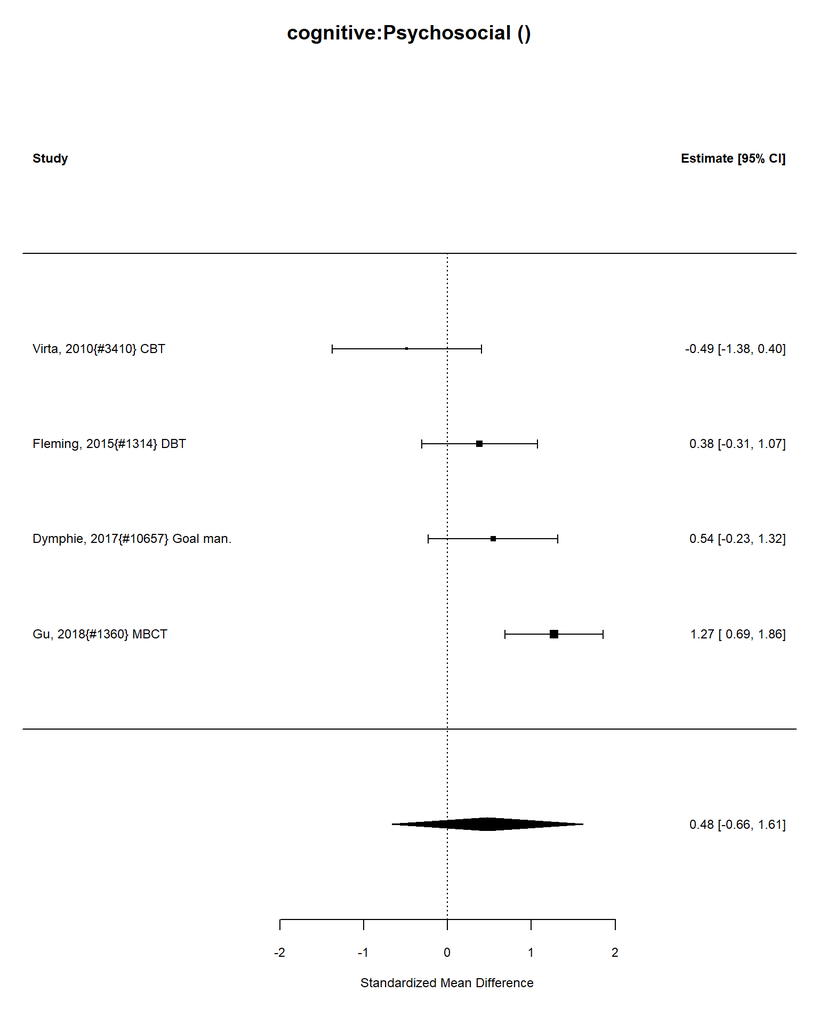

| estimate | conf.low | conf.high |
| --- | --- | --- |
| 0.48 | -0.66 | 1.61 |

Number of studies = 4

Intervention sample = 67

Control sample = 67

Total sample = 134.

I-squared = 73 %

Convert Effect Size to Real Units

Estimated effect in original units = 8.28.

##### Publication Bias Tests

###### Begg (non-parametric)

Rank Correlation Test for Funnel Plot Asymmetry Kendall’s tau = -0.6667, p = 0.3333

###### Egger (parametric)

Regression Test for Funnel Plot Asymmetry

Model: mixed-effects meta-regression model Predictor: standard error

Test for Funnel Plot Asymmetry: t = -3.7428, df = 2, p = 0.0645 Limit Estimate (as sei -> 0): b = 4.2696 (CI: 0.0065, 8.5328)

###### Trim and Fill

Estimate and Cis

|  | estimate | ci.lb | ci.ub |
| --- | --- | --- | --- |
| intrcpt | 0.75 | -0.04 | 1.55 |

### Meta-regression: stimulant vs non-stimulant

0 stimulant studies

0 nonstimulant studies

Not enough studies to compare stimulant and nonstimulant

### Meta-regression: AMPH vs MPH

### AMPH vs MPH meta-regression

0n AMPH studies

0 nMPH studies

Not enough studies to compare AMPH and MPH

## Meta-regression: Indirect comparison between combined vs(medication plus psychosocial) and medication

0 medication studies

0 combined studies

Not enough studies to compare medication and combined